# Lecture 1 - Introduction

The Social Brain: Critical Perspectives on Science, Society and Neurodiversity

Richard Ramsey

## Today

Part 1

- Introduction to the course

Part 2

- Read articles and discuss

[figure not shown]

# Part 1 - Introduction

## Who will be teaching?

- Dr. Richard Ramsey
- Please just call me Rich

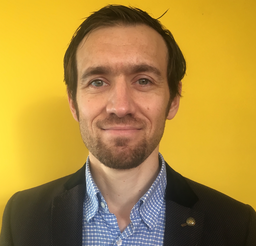

- I’m originally from Leeds (UK)
- BSc. and PhD (University of Birmingham, UK)
- Postdoctoral work (UK and Belgium)
- Since 2011, I’ve co-directed a cognitive neuroscience lab as a faculty member at Bangor University (UK) and Macquarie University (Australia)
- I’ve been at ETH since 2023

## What are my lab’s research interests?

**Themes**

- Cognitive neuroscience
- Person perception
- Loneliness
- Meta science
- Open science

[figure not shown]

**Methods**

- Experimental psychology
- Human neuroscience (e.g., fMRI)
- “Big Data”
- Computational modelling
- Pupillometry

[https://www.rich-ramsey.com]

## Course website

[figure not shown]

- [Course website](https://rich-ramsey.github.io/tsb/)
- This has all the good stuff
- Let’s take a look…

## Contact details

- Speak to me in class - this is the best place to raise questions and discuss ideas.
- Email: richard.ramsey [at] hest.ethz.ch

[figure not shown]

## Notes on lectures

- Slides will be posted on the course website before each lecture.
- **Most important of all:** if you don’t understand something, then **PLEASE** interrupt me and ask a question. No doubt other students in the class are stuck with the same issue.

[figure not shown]

[figure not shown]

[figure not shown]

# Part 1 - Syllabus

## Course content

**Themes**

- Research quality and integrity
- Social neuroscience
- Neurodiversity

**Skills**

- Critical evaluation of scientific evidence, data and theory
- Develop independent thinking skills
- Appreciate how understanding neurodiversity impacts basic research and society in general

## Learning Outcomes

- To examine critically how neuroscientific concepts, theories, and findings relate to broader historical, moral, and social contexts, enhancing reflective competencies.
- To question the production and validation of scientific evidence within the context of the replication crisis, enabling students to evaluate how knowledge is created, validated, and communicated.
- To understand how conceptualising cognitive variation as a natural continuum challenges deficit-focused models, promoting more inclusive frameworks for society.
- To develop effective communication skills for translating complex scientific concepts to diverse audiences, fostering public understanding of science.

## Format

- Lectures will be split into two sections with a short break in the middle.
- I will present material in the first half.
- In the second half, students will break into small groups and have time to read and discuss relevant papers from that week’s material.

[figure not shown]

## Small group work

- Students have the opportunity to discuss any questions arising from the previous lecture, as well as coursework.
- A journal article will be provided from the previous lecture as a starting point for this discussion.
- Group discussion sessions are an excellent way to clarify understanding and develop ideas for your assignment.

## Schedule

| Week | Date | Title | Description |
| --- | --- | --- | --- |
| 1 | Sep 16 | Intro | Introduction to the course |
| 2 | Sep 23 | Crisis Part 1 | Is psychological science in a crisis? |
| 3 | Sep 30 | Crisis Part 2 | The reform movement in psychological science |
| 4 | Oct 7 | Crisis Part 3 (Recorded lecture) | A problem in theory? |
| 5 | Oct 14 | Crisis Part 4 (No lecture - reflective writing) | Does the crisis extend beyond psychology? |
| 6 | Oct 21 | Social Neuroscience 1 | An introduction to social neuroscience |
| 7 | Oct 28 | Social Neuroscience 2 | Reading faces and bodies |
| 8 | Nov 4 | Social Neuroscience 3 | Understanding others |
| 9 | Nov 11 | Neurodiversity 1 | Re-thinking neurodiversity |
| 10 | Nov 18 | Neurodiversity 2 | Guest lecture: A view from the clinic |
| 11 | Nov 25 | Neurodiversity 3 | Loneliness |
| 12 | Dec 2 | Neurodiversity 4 | Autism |
| 13 | Dec 9 | Neurodiversity 5 | Attention and impulsivity |
| 14 | Dec 16 | Essay Writing | Guidelines and best practices |

## Topics

- Introduction
- Crisis and reform
- Social neuroscience
- Neurodiversity
- Essay writing Q&A

# Part 1 - Assessment

## Assessment format

You can write your essay in two different ways.

**1. Address a general question.**

e.g., Is psychology a science or a pseudoscience?

**2. Address a more specific question.**

e.g., Should Autism be considered one diagnosis or multiple different diagnoses?

**You decide the focus of your essay based on what you find interesting.**

## Assessment structure

Example structure (it seems obvious, but nonetheless…):

- Introduction
- Main body of the essay
- Conclusion

## Assessment content

Things to cover:

- Identify an open research question, which warrants further attention
- Provide a brief background to the topic
- Highlight a gap in knowledge (what we do not know)
- Be critical
- Identify a novel research question or research direction
- State your hypotheses and/or aims
- Discuss the implications of the research (why is it worth doing?)

# Part 1 - Writing tips

## Narrow focus

- Your essay should have a narrow focus, I do not want a detailed literature review.
- You are not being assessed on the breadth of your knowledge. Therefore, I will not mark you down for having a narrow focus.
- However, I expect a very clear and well-supported rationale for your critical viewpoint and future direction.
- I will reward attempts to think on your own

## Keep it simple !!!

- Find an experiment or topic from my lectures that interests you
- Go away and read around the topic
- Think of a feature that limits understanding – i.e., be critical – and suggest a way to extend current knowledge

## Plan, plan and plan some more

- Plan your written assignment BEFORE you start to write. You will find it easier to write if you organise your ideas first into a structure.
- Consider the balance of your assignment, in terms of the amount of text per section.
- Make multiple plans, rather than one. One page A4 per plan.
- Review the plans and consider revision and/or consolidation.

## Writing style

- Clarity is crucial
- If you can say it with less words, do so (i.e., keep sentences short).
- Try to link paragraphs to promote the flow and pace of your writing
- Have a friend or classmate read it

# Part 1 - Reflective writing

## Week 5

- In week 5, there is no lecture.
- Instead, there is an assignment, which is **NOT** marked.
- I repeat, it is **not marked**, but it is compulsory to hand it in via email by *Monday October 20th at 9am*.
- Please write between 500 and 750 words on the extent to which the reproducibility crisis extends beyond psychology and human neuroscience.

## Reflective writing objectives

- I would like you to reflect on the extent to which the reproducibility crisis extends beyond psychology and human neuroscience.
- Most of you have varied backgrounds, which span computer science, physics, chemistry, biology, maths etc.
- Therefore, I would like you to situate what you have learnt in the last 4 weeks within a broader context of scientific research more generally.

# Part 1 - Summary

- Introduction
- Syllabus
- Assessment
- Writing tips
- Reflective writing

# Take a break

# Part 2 - Read articles and discuss

## Discussion material

- Here are some accessible (i.e., non-technical) blog posts that cover the main themes in the course.
- Read these to kick-start a discussion in your group.
- [Crisis and reform](https://rich-ramsey.com/posts/2023-05-16_meta_science/)
- [Social neuroscience](https://focuskeeper.co/glossary/what-is-social-neuroscience)
- [Neurodiversity](https://www.london.ac.uk/news-events/student-blog/neurodiversity-hidden-superpower)

## Acknowledgements

- Unless otherwise specified, icons and images were used under license from [The Noun Project](https://thenounproject.com/)
- Slides were created with [Quarto](https://quarto.org/) and [RevealJS](https://revealjs.com/)